This lab is aimed at detailing the intricacies of tidy data and joins. As with anything we do in this course, it will continue to build on previous concepts, as such programmatic techniques may be leveraged in this lab as well. We will take each in turn, begging first with the `pivot` functions that are so characteristic of tidying up data.

As per usual, you will have some code chunks with templates that you will have to complete. Remove the `eval = FALSE` header to get the code chunk to run to completion.

# 1 Tidy Data

I am first creating an artificial data set that chronical the number and type of vacation destinations in a given year from 2006 to 2020. As such, there are 45 total rows, each indicating a year, destination, and number.

```r
library(tidyverse)
set.seed(123)
vaca <- data.frame(year = rep(seq(2006, 2020), each = 3), location = rep(c("beach", "moutain", "lake"), 15), N = round(runif(45, 10,100)))
head(vaca)
```

```
##   year location  N
## 1 2006    beach 36
## 2 2006  moutain 81
## 3 2006     lake 47
## 4 2007    beach 89
## 5 2007  moutain 95
## 6 2007     lake 14
```

## 1.1

Currently the data is in *long* format, but imagine we would like it be wide instead. That is, imagine what would be a more compact form of this data set where each type of destination was a column, each singular year was a row and the intersection contained the number corresponding to each. Create such a data set and call it `vaca.wide`. Print the entirety of the data set, and comment on why it is not necessary to just print the head of this particular data set. (1pt)

```r
#Use a pivot command
vaca.wide <- pivot_wider(vaca, names_from = location, values_from = N)
print(vaca.wide)
```

```
## # A tibble: 15 x 4
##     year beach moutain  lake
##    <int> <dbl>   <dbl> <dbl>
##  1  2006    36      81    47
##  2  2007    89      95    14
##  3  2008    58      90    60
##  4  2009    51      96    51
##  5  2010    71      62    19
##  6  2011    91      32    14
##  7  2012    40      96    90
##  8  2013    72      68    99
##  9  2014    69      74    59
## 10  2015    63      36    23
## 11  2016    97      91    72
## 12  2017    82      12    53
## 13  2018    78      29    39
## 14  2019    31      23    47
## 15  2020    47      43    24
```

It is necessary to print more than the head of this dataset as it would otherwise not necessarily show each year, failing to indicate whether the data pivoted fully.

## 1.2

One reason that a wider data frame may be advisable in the above scenario is that it is conducive to some of the low level EDA we discussed in the previous lab. That is, instead of having to loop over destination types, or even just specify them within a more complicated command, we can now just find column means to summarise the number of people attending each destination spot. Let’s try: find the destination with the largest average number of visitors. Also find the standard deviation of this destination and comment on how this variability may affect your conclusion regarding the “most popular destination”. (1pt)

```r
vaca.wider<-as.data.frame(vaca.wide)
colMeans(vaca.wider)
```

```
##       year      beach    moutain       lake
## 2013.00000   65.00000   61.86667   47.40000
```

```r
sd(vaca.wider[,2])
```

```
## [1] 20.75366
```

The variability at the beach, swinging well outside of the range of most popular, means that in any given year, there is no guarantee the beach actually IS the most popular, only that it averages the most visitors.

## 1.3

Now, find the year with the most cumulative visitors. How many visitors did this year see? (1 pt)

```r
cum_vaca_wider <- mutate(vaca.wider, cum_visitors = beach + moutain + lake)
max(cum_vaca_wider[,5])
```

```
## [1] 260
```

```r
cum_vaca_wider[11,1]
```

```
## [1] 2016
```

## 1.4

Now even though some of the arithmetic EDA is expedited by making the data frame wider, most of ggplot will prefer the data to be oriented in a long fashion.

To illustrate this, create a new data set called `vaca.abbridge.long` contains only the years 2011-2020 in long format. From there, create a line plot of the data colored by destination [^1]. Interpret this line plot in the context of the “most popular vacation destination”. (2 pt)

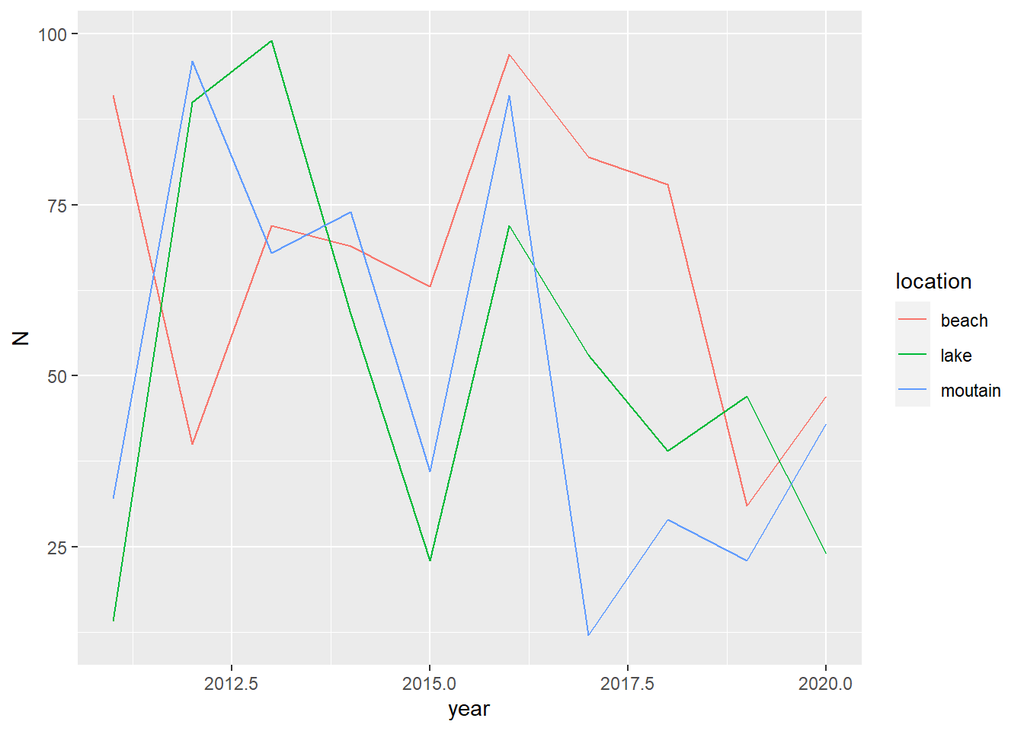

```r
vaca.abbridge.long <- filter(vaca, year >= 2011)

vaca.abbridge.long %>%
  ggplot(aes(x = year, y = N, color = location)) +
  geom_line()
```

This line plot clearly shows that the most popular vacation spot changes. In 2011, it was the beach, then in 2012 it was the mountains, in 2013 it was the lake, and the values kept fluctuating.

## 1.5

Based on the plot above *guess* which destination has the most variability in its popularity. Check this intution using the `sd` command. (1pt)

```r
sd(vaca.wider$beach)
```

```
## [1] 20.75366
```

```r
sd(vaca.wider$moutain)
```

```
## [1] 30.01634
```

```r
sd(vaca.wider$lake)
```

```
## [1] 26.28362
```

Based on the plot, it looks like the mountains have the most variability.

# 2 Joins

We will again begin with an artificial data set.

```r
set.seed(123)

employee_id <- 1:10
employee_name <- c("Andrew", "Ellen", "Ethan", "Joe", "Johann",
                   "Jacob", "Jennica", "Charlotte", "Jacqueline", "Ivy")
employee_salary <- round(rnorm(10, mean = 1500, sd = 200))
employee_age <- round(rnorm(10, mean = 50, sd = 8))
employee_position <- c("CTO", "CFO", "Administrative", rep("Technician", 7))


df_1 <- data.frame(id = employee_id[1:8], name = employee_name[1:8],
                   month_salary = employee_salary[1:8])
df_2 <- data.frame(id = employee_id[-5], name = employee_name[-5],
                   age = employee_age[-5], position = employee_position[-5])

df_1
```

```
##   id      name month_salary
## 1  1    Andrew         1388
## 2  2     Ellen         1454
## 3  3     Ethan         1812
## 4  4       Joe         1514
## 5  5    Johann         1526
## 6  6     Jacob         1843
## 7  7   Jennica         1592
## 8  8 Charlotte         1247
```

```r
df_2
```

```
##   id       name age       position
## 1  1     Andrew  60            CTO
## 2  2      Ellen  53            CFO
## 3  3      Ethan  53 Administrative
## 4  4        Joe  51     Technician
## 5  6      Jacob  64     Technician
## 6  7    Jennica  54     Technician
## 7  8  Charlotte  34     Technician
## 8  9 Jacqueline  56     Technician
## 9 10        Ivy  46     Technician
```

As you can see, the each data frame has an employee designated by name and `id`. The first dataframe, then, has monthly salary, while the second contains age and position.

## 2.1

Create a new dataframe, called `df_3`, that is comprised of the *common elements* of `df_1` and `df_2`. *Hint* notice that each name is unique, so it can identify observations as easily as the variable `id`. (1 pt)

```r
# use a correct join command with carefully chosen key
df_3 <- df_1 %>% inner_join(df_2, by = "name")
df_3
```

```
##   id.x      name month_salary id.y age       position
## 1    1    Andrew         1388    1  60            CTO
## 2    2     Ellen         1454    2  53            CFO
## 3    3     Ethan         1812    3  53 Administrative
## 4    4       Joe         1514    4  51     Technician
## 5    6     Jacob         1843    6  64     Technician
## 6    7   Jennica         1592    7  54     Technician
## 7    8 Charlotte         1247    8  34     Technician
```

## 2.2

We now would like to create a new dataframe, `df_4`, that includes all elements from both dataframe, irrespective of whether or not they are shared. Note, this may induce some `NA's` which we will have to attend to in future work [^2]. (1 pt)

```r
#another join command
df_4 <- df_1 %>% full_join(df_2, by = 'name')
df_4
```

```
##    id.x       name month_salary id.y age       position
## 1     1     Andrew         1388    1  60            CTO
## 2     2      Ellen         1454    2  53            CFO
## 3     3      Ethan         1812    3  53 Administrative
## 4     4        Joe         1514    4  51     Technician
## 5     5     Johann         1526   NA  NA           <NA>
## 6     6      Jacob         1843    6  64     Technician
## 7     7    Jennica         1592    7  54     Technician
## 8     8  Charlotte         1247    8  34     Technician
## 9    NA Jacqueline           NA    9  56     Technician
## 10   NA        Ivy           NA   10  46     Technician
```

## 2.3

We now have missing monthly salary for both Ivy and Jacqueline. Recall that there are multiple ways to handle this, but because we do have *some* information on their status, we can leverage this to interpolate their possible salaries. That is, for each of Jacqueline and Ivy, produce monthly salary estimates via linear interpolation of the three technicians closest in age to the given person. Finally, place these projected values into the appropriate place in the dataframe below. *Hint Use the `approxfun()` command using salary and age as your two input vectors. Recall that this approxfun() will return a function performing interpolation on the given data points. We can then submit the known ages for the two women to this function and it will return the interpolated salary for that age.* (2 pt)

```r
#initialize salary and age input vectors for both Jacqueline and Ivy based on the available information of other workers

my_approx_fun<-approxfun(df_4$age, df_4$month_salary, method = 'linear', n = 3)
Jacq_salary<-my_approx_fun(56)

my_approx_fun<-approxfun(df_4$age, df_4$month_salary, method = 'linear', n = 3)
Ivy_salary<-my_approx_fun(46)

df_4[9,3]<-Jacq_salary
df_4[10,3]<-Ivy_salary

df_4
```

```
##    id.x       name month_salary id.y age       position
## 1     1     Andrew     1388.000    1  60            CTO
## 2     2      Ellen     1454.000    2  53            CFO
## 3     3      Ethan     1812.000    3  53 Administrative
## 4     4        Joe     1514.000    4  51     Technician
## 5     5     Johann     1526.000   NA  NA           <NA>
## 6     6      Jacob     1843.000    6  64     Technician
## 7     7    Jennica     1592.000    7  54     Technician
## 8     8  Charlotte     1247.000    8  34     Technician
## 9    NA Jacqueline     1524.000    9  56     Technician
## 10   NA        Ivy     1435.471   10  46     Technician
```

[^1]: This would take you an additional three lines of code to accomplish if you were still in wide formatting
[^2]: An alternative, albeit less efficient and robust, method of achieving each of the above tasks is the `merge()` command. This has an additional argument that will distinguish between the types of join rather than using entirely different functions.